# Instructions

For this assignment, you will need the following libraries but feel free to use any other library.

- scikit-learn
- mlxtend
- matplotlib
- numpy

**Write your roll number below, which will be used as a random seed value in the code so that each student's results are different.**

```python
import sklearn
import mlxtend
import matplotlib
import numpy as np
```

```python
import matplotlib.pyplot as plt
```

```python
roll_number = 231453415
```

# 1- Download handwritten digits dataset called "mnist"

For this, code is already given below. The variable X contains the images. Each image is flattenend in a vector (1D array). There are total 5000 images. Each image has a resolution of 28x28 (which when converted to a vector make 784 dimensions). The variable y has 5000 labels corresponding to each image. The value of labels is between 0-9, representing the handwritten digit it represents. Thus, its a multiclass classification problem where given an input image, we have to predict it's class out of all possible 10 classes.

Execute the following cell to get the data and it's labels.

```python
from mlxtend.data import mnist_data
X, y = mnist_data()
```

# 2- Visualizing the data

- Write a python function, that takes a 1D array of 784 dimensions and reshapes it to a 28x28 image and displays it.
- Test this function on the first image in X.

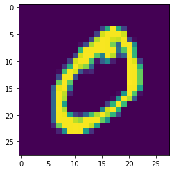

```python
# TO DO, IMAGE RESHAPE AND DISPLAY FUNCTION
def reshapeImage(arg):
    if (len(arg) == 784):
        rshpImg = arg.reshape(28, 28)
        imgplot = plt.imshow(rshpImg)
        plt.show(imgplot)
    else:
        print("Dimension of input array is not 1 x 784!")
reshapeImage(X[0])
```

# 3- Splitting the data into train and test

- Write a python function that takes the data X and the labels y, and splits it into two partitions for train and test respectively. This will give you X_train, y_train, X_test, and y_test.
- Use scikit-learn (also called sklearn) for this purpose. Use stratify split based on labels so that for each class, same ratio is maintained in both the splits. Use your roll number defined above as random seed so that each student gets different splits.
- Plot the first image in X_test using the function defined in task 2 above.

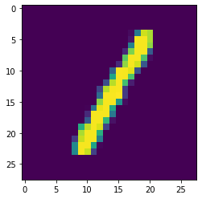

```
1
```

```python
# TO DO: STRATIFY SPLIT INTO TRAIN AND TEST
from sklearn.model_selection import train_test_split

X_train, X_test, y_train, y_test = train_test_split(X, y, stratify=y, random_state=roll_number, test_size=0.2)
reshapeImage(X_test[0])
print(y_test[0])
```

# 4- Naive Bayes Classification

- Train a naive bayes model on train split and get predictions on test split. Write the code to calculate and print the time it took to train the model.
- Use the predictions to compute the accuracy.
- Use the predictions to compute and print class-wise Precision, Recall, and F1-score.
- Use the predictions to compute and print micro and macro average Precision, Recall and F1-score. Also, save macro averages all these three metrics in variables (or a dictionary) as we are going to use them later.
- Write a function that takes predicted and actual label arrays and prints a confusion matrix. Use sklearn for that as well.

Sample confusion matrix is shown below:

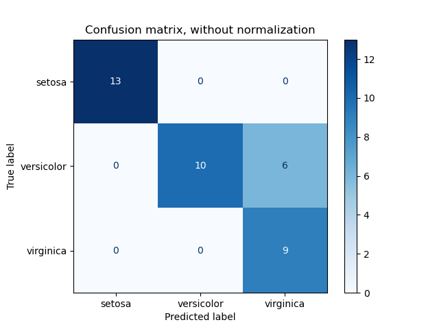

```
Time taken to train the model: 0.019794940948486328s
Accuracy:  0.585
Classwise Classification Report:
               precision    recall  f1-score   support

           0       0.74      0.95      0.83       100
           1       0.67      0.89      0.77       100
           2       0.84      0.43      0.57       100
           3       0.71      0.42      0.53       100
           4       0.72      0.13      0.22       100
           5       0.53      0.10      0.17       100
           6       0.72      0.88      0.79       100
           7       0.81      0.44      0.57       100
           8       0.31      0.72      0.43       100
           9       0.48      0.89      0.63       100

    accuracy                           0.58      1000
   macro avg       0.65      0.58      0.55      1000
weighted avg       0.65      0.58      0.55      1000


Confusion Matrix:
```

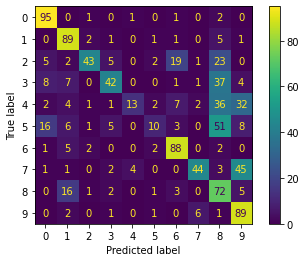

```
Micro Average Evaluation Metrics:
Precision: 0.585
Recall: 0.585
F1 score: 0.585
Support: None

Macro Average Evaluation Metrics:
Precision: 0.6544272046666432
Recall: 0.585
F1 score: 0.5507980975948119
Support: None
```

```python
# TO DO: NAIVE BAYES CLASSIFICATION, PREDICTIONS, AND METRICS
from sklearn.naive_bayes import GaussianNB
from sklearn.metrics import accuracy_score, classification_report
from sklearn.metrics import confusion_matrix, ConfusionMatrixDisplay
import time
from sklearn.metrics import accuracy_score, precision_recall_fscore_support


nb = GaussianNB() # Gaussian Naive Bayes Model
start = time.time() # Start timer
nb.fit(X_train, y_train) # Model train
end = time.time() # End timer

print("Time taken to train the model:",end-start,end="s\n")
y_pred = nb.predict(X_test) # Model prediction

accuracy = accuracy_score(y_test, y_pred) # Model Accuracy
c_report = classification_report(y_test, y_pred) # Classification report for class-wise evaluation

print("Accuracy: ", accuracy)
print("Classwise Classification Report: \n", c_report)

def conMat(test, pred): # Confusion matrix display function
    con_matrix = confusion_matrix(test, pred, labels=nb.classes_)
    print("\nConfusion Matrix: ")
    con_matrix = ConfusionMatrixDisplay(con_matrix, display_labels=nb.classes_)
    con_matrix.plot()
    plt.show()

conMat(y_test, y_pred)


nbMac = {}
nbMac['precision'], nbMac['recall'], nbMac['f1score'], nbMac['support'] = precision_recall_fscore_support(y_test, y_pred, average = 'macro') # Micro average evaluation metrics

nbMic = {}
nbMic['precision'], nbMic['recall'], nbMic['f1score'], nbMic['support'] = precision_recall_fscore_support(y_test, y_pred, average = 'micro') # Macro average evaluation metrics

print("\nMicro Average Evaluation Metrics:")
print("Precision:",nbMic['precision'])
print("Recall:",nbMic['recall'])
print("F1 score:",nbMic['f1score'])
print("Support:",nbMic['support'])


print("\nMacro Average Evaluation Metrics:")
print("Precision:",nbMac['precision'])
print("Recall:",nbMac['recall'])
print("F1 score:",nbMac['f1score'])
print("Support:",nbMac['support'])
```

# 5- Apply PCA

- Use sklearn PCA module to compute PCA on train split.
- Transform train split using computed PCA eigenvectors and only select top 20 principal components.
- Transform test split using computed PCA eigenvectors and only select top 20 principal components.
- Take first two components for each record in test split and plolt them using a scatter plot. Now each record will be a datapoint on a 2D scatter plot. Assign them colors based on the labels of the test split (i.e., if a datapoint has label 0, it can be shown in black color, if a datapoint has label 1, it can be shown in red color and so on). This will help us visualizing the **clusters** of data point which has same label. Use matplotlib for this task (and it is really easy to do in matplotlib).
- Again use Naive Bayes to train and test the model on this PCA transformed data and calculate and print the time it took to train the model.
- Again compute and print the accuracy on the test split.
- Print the class-wise Precision, Reall, and F1-score computed on the test split.
- Print the micro and macro average Precision, Recall and F1-score computed on test split. Also, save macro averages of all these three metrics in variables (or a dictionary) as we are going to use them later.
- Use the function defined in Task 4 to compute and print the confusion matrix.

Sample PCA scatter plot with colored datapoints with respect to each class label is shown below:

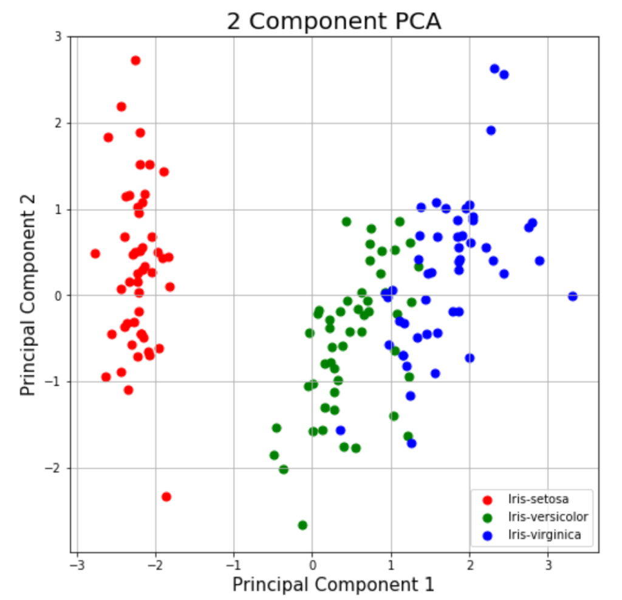

```
Scatter Plot after PCA():
```

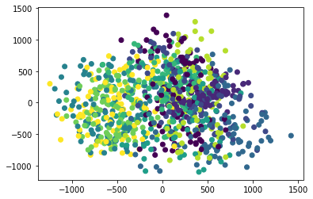

```
Time taken to train the model: 0.0023763179779052734s
Accuracy:  0.852
Classwise Classification Report:
               precision    recall  f1-score   support

           0       0.96      0.93      0.94       100
           1       0.88      0.91      0.90       100
           2       0.92      0.79      0.85       100
           3       0.84      0.87      0.86       100
           4       0.78      0.91      0.84       100
           5       0.71      0.79      0.75       100
           6       0.88      0.89      0.89       100
           7       0.92      0.87      0.89       100
           8       0.84      0.82      0.83       100
           9       0.83      0.74      0.78       100

    accuracy                           0.85      1000
   macro avg       0.86      0.85      0.85      1000
weighted avg       0.86      0.85      0.85      1000


Confusion Matrix:
```

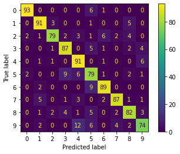

```
Micro Average Evaluation Metrics:
Precision: 0.852
Recall: 0.852
F1 score: 0.852
Support: None

Macro Average Evaluation Metrics:
Precision: 0.8560535739575332
Recall: 0.852
F1 score: 0.8524426437843713
Support: None
```

```python
# TO DO: APPLY PCA AND RUN NAIVE BAYES AGAIN
from sklearn.decomposition import PCA


pca = PCA(n_components = 20) # Principal Component Analysis dimensionality reduction model
pca.fit(X_train)  # Model fit

X_trainTrans = pca.transform(X_train) # Transforming X_train
X_testTrans = pca.transform(X_test) # Transforming X_test

print("Scatter Plot after PCA():")
plt.scatter(X_testTrans[:,1],X_testTrans[:,2],c=y_test) # Sactter plot of the PCA reduced model (first two components)
plt.show()

nb2 = GaussianNB() # Gaussian Naive Bayes Model
start2 = time.time()
nb2.fit(X_trainTrans, y_train) # Model train
end2 = time.time()

print("Time taken to train the model:",end2-start2,end="s\n")
y_pred = nb2.predict(X_testTrans) # Model prediction

accuracy2 = accuracy_score(y_test, y_pred) # Model Accuracy
c_report2 = classification_report(y_test, y_pred) # Classification report for class-wise evaluation

print("Accuracy: ", accuracy2)
print("Classwise Classification Report: \n", c_report2)


conMat(y_test, y_pred)

nb2Mac = {}
nb2Mac['precision'], nb2Mac['recall'], nb2Mac['f1score'], nb2Mac['support'] = precision_recall_fscore_support(y_test, y_pred, average = 'macro') # Micro average evaluation metrics

nb2Mic = {}
nb2Mic['precision'], nb2Mic['recall'], nb2Mic['f1score'], nb2Mic['support'] = precision_recall_fscore_support(y_test, y_pred, average = 'micro') # Macro average evaluation metrics

print("\nMicro Average Evaluation Metrics:")
print("Precision:",nb2Mic['precision'])
print("Recall:",nb2Mic['recall'])
print("F1 score:",nb2Mic['f1score'])
print("Support:",nb2Mic['support'])


print("\nMacro Average Evaluation Metrics:")
print("Precision:",nb2Mac['precision'])
print("Recall:",nb2Mac['recall'])
print("F1 score:",nb2Mac['f1score'])
print("Support:",nb2Mac['support'])
```

# 6- PCA with 96% variance

- Now instead of selecting top 20 principal components, select the number of components which account for a cummulative variance of 96% at least. (This is really easy to do in sklearn)
- **Note:** Each student will get different number of components that make a commulative variance of 96%
- Take first two components for each record in test split and plot them using a scatter plot. Now each record will be a datapoint on a 2D scatter plot. Assign them colors based on the labels of the test split just like part 5 above.
- Transform train split using computed PCA eigenvectors with 96% commulative variance.
- Transform test split using computed PCA eigenvectors with 96% commulative variance..
- Again use Naive Bayes to train and test the model on this PCA transformed data and calculate and print the time it took to train the model.
- Again compute and print the accuracy on the test split.
- Print the class-wise Precision, Reall, and F1-score computed on the test split.
- Print the micro and macro average Precision, Recall and F1-score computed on test split. Also, save macro avarage of all these three metrics in variables (or a dictionary) as we are going to use them later.
- Use the function defined in Task 4 to compute and print the confusion matrix.

```
Scatter Plot after PCA(n_components=0.96):
```

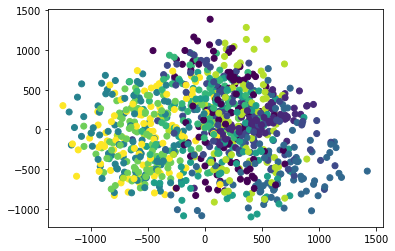

```
Time taken to train the model: 0.0024313926696777344s
Accuracy:  0.852
Classwise Classification Report:
               precision    recall  f1-score   support

           0       0.96      0.93      0.94       100
           1       0.88      0.91      0.90       100
           2       0.92      0.79      0.85       100
           3       0.84      0.87      0.86       100
           4       0.78      0.91      0.84       100
           5       0.71      0.79      0.75       100
           6       0.88      0.89      0.89       100
           7       0.92      0.87      0.89       100
           8       0.84      0.82      0.83       100
           9       0.83      0.74      0.78       100

    accuracy                           0.85      1000
   macro avg       0.86      0.85      0.85      1000
weighted avg       0.86      0.85      0.85      1000


Confusion Matrix:
```

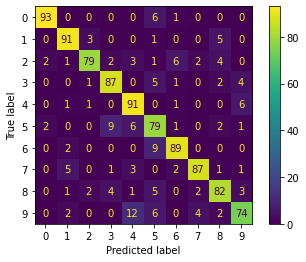

```
Micro Average Evaluation Metrics:
Precision: 0.852
Recall: 0.852
F1 score: 0.852
Support: None

Macro Average Evaluation Metrics:
Precision: 0.8560535739575332
Recall: 0.852
F1 score: 0.8524426437843713
Support: None
```

```python
# TO DO: COMMULATIVE VARIANCE 96% FOR PCA AND RUN NAIVE BAYES AGAIN

pca2 = PCA(n_components = 0.96) # Principal Component Analysis dimensionality reduction model with 96% variance
pca2.fit(X_train) # Model fit

X_trainTrans2 = pca2.transform(X_train) # Transforming X_train
X_testTrans2 = pca2.transform(X_test) # Transforming X_test

print("Scatter Plot after PCA(n_components=0.96):")
plt.scatter(X_testTrans2[:,1],X_testTrans2[:,2],c=y_test) # Sactter plot of the PCA(n_components=0.96) reduced model (first two components)
plt.show()

nb3 = GaussianNB() # Gaussian Naive Bayes Model
start3 = time.time()
nb3.fit(X_trainTrans, y_train) # Model train
end3 = time.time()

print("Time taken to train the model:",end3-start3,end="s\n")
y_pred = nb3.predict(X_testTrans) # Model prediction

accuracy3 = accuracy_score(y_test, y_pred) # Model Accuracy
c_report3 = classification_report(y_test, y_pred) # Classification report for class-wise evaluation

print("Accuracy: ", accuracy3)
print("Classwise Classification Report: \n", c_report3)


conMat(y_test, y_pred)

nb3Mac = {}
nb3Mac['precision'], nb3Mac['recall'], nb3Mac['f1score'], nb3Mac['support'] = precision_recall_fscore_support(y_test, y_pred, average = 'macro') # Micro average evaluation metrics

nb3Mic = {}
nb3Mic['precision'], nb3Mic['recall'], nb3Mic['f1score'], nb3Mic['support'] = precision_recall_fscore_support(y_test, y_pred, average = 'micro') # Macro average evaluation metrics

print("\nMicro Average Evaluation Metrics:")
print("Precision:",nb3Mic['precision'])
print("Recall:",nb3Mic['recall'])
print("F1 score:",nb3Mic['f1score'])
print("Support:",nb3Mic['support'])


print("\nMacro Average Evaluation Metrics:")
print("Precision:",nb3Mac['precision'])
print("Recall:",nb3Mac['recall'])
print("F1 score:",nb3Mac['f1score'])
print("Support:",nb3Mac['support'])
```

# 7- Plot Metrics

- Use matplotlib to make a grouped barplot for each of the three metrics saved for Tasks 4,5, and 6. So now you will have 9 bars in total (3 for macro average precision, 3 for macro average recall, 3 for macro average F1).
- Set x-axis labels of this barplot to the Task number against which you computed those values.
- Set color of the bars such that for each task, macro precision has same color, macro recall has same color, and macro F1 has the same color.
- Show legend on the barplot so that we know which color represents which metric.

Sample is shown below:

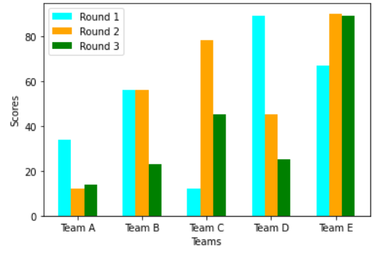

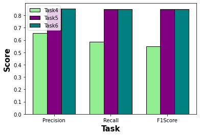

```python
# TO DO: PLOTTING

x_axis = np.arange(3)
data1 = [nbMac['precision'], nbMac['recall'], nbMac['f1score']]
data2 = [nb2Mac['precision'], nb2Mac['recall'], nb2Mac['f1score']]
data3 = [nb3Mac['precision'], nb3Mac['recall'], nb3Mac['f1score']]

plt.bar(x_axis - 0.25, data1, color='lightgreen', width=0.25, edgecolor='black')
plt.bar(x_axis + 0.0, data2, color='purple', width=0.25, edgecolor='black')
plt.bar(x_axis + 0.25, data3, color='teal', width=0.25, edgecolor='black')
plt.xlabel('Task', fontweight ='bold', fontsize = 15)
plt.ylabel('Score', fontweight ='bold', fontsize = 15)
plt.xticks(x_axis, ['Precision', 'Recall', 'F1Score'])
plt.legend(["Task4", "Task5", "Task6"])
plt.show()
```

# 8- Comments

Comment on the following:

- Which variation took the least time to train the model?
- Which variation has the highest accuracy?
- Which variation has the highest Macro-F1 score?
- Is there any difference in micro and macro avarage Precision, Recall, and F1-score? If yes, why is that so? If no, why there is no difference?
- For part 6, for which class lable the model is least accurate and with which class it is **confusing** the least accuratly predicted class?
- Which part produced more accurate clusters when visualizing in scatter plot. Part 5 or part 6?